# week12

Evan Knep

2024-04-21

```r
# Script Settings And Resources
setwd(dirname(rstudioapi::getActiveDocumentContext()$path))
library(tidyverse)
library(RedditExtractoR)
library(tm)
library(qdap)
```

```r
library(SnowballC)
library(RWeka)
library(ldatuning)
library(wordcloud)
library(topicmodels)
library(tidytext)
library(psych)
library(caret)
library(parallel)
library(doParallel)
```

# Data Import and Cleaning

```r
# urls <- find_thread_urls(subreddit = "IOPsychology", sort_by = "top", period = "year")
# reddit <- get_thread_content(urls$url)
# week12_tbl <- as_tibble(reddit$threads) %>%
#   select(c('title', 'upvotes'))
# write_csv(week12_tbl, "../data/reddit_IO_data.csv")
week12_tbl <- read_csv("../data/reddit_IO_data.csv")
week12_tbl$title
```

```
##   [1] "WOP-P"
##   [2] "Any recommendations for IO Psychology graduate programs?"
##   [3] "Challenge finding a career according to personality"
##   [4] "Anyone knows any research on relationship between PERCEIVED ORGANIZATION POLITICS and TURNOVER INTENTION. ???"
##   [5] "Talent review"
##   [6] "Join my psychology and typology based discord server! 18+"
##   [7] "Ideas"
##   [8] "Please help me answer this question"
##   [9] "Is police or a start up businnes more transactional"
##  [10] "Bank CEO leadership"
##  [11] "Looking on SIOP website for call for proposals for 2024 conference"
##  [12] "Any good bachelors programs for I/O psychology in California?"
##  [13] "Bi-Weekly /r/IOpsychology Discussion - What have you been reading, and what do you think of it?"
##  [14] "Help"
##  [15] "How will we test AIs for IQ?"
```

[output cut: 595 more lines]

```r
io_corpus_original <- VCorpus(VectorSource(week12_tbl$title))
```

```r
io_corpus <- io_corpus_original %>%
  tm_map(content_transformer(str_to_lower)) %>%
  tm_map(removeWords, c("io", "psychology", "psych", "i/o", "r/iopsychology")) %>%
  tm_map(content_transformer(replace_abbreviation)) %>%
  tm_map(content_transformer(replace_contraction)) %>%
  tm_map(removeNumbers) %>%
  tm_map(removePunctuation) %>%
  tm_map(removeWords, stopwords("en")) %>%
  tm_map(stripWhitespace) %>%
  tm_map(stemDocument, language = "english")
```

*My corpus pre-processing steps went as follows:* 1. str_to_lower. Doing this first because then when I filter out words I don’t need to worry about capitalization of each word being treated differently 2. removeWords. Removing all words related to IO psychology. Started with the basics: io, psychology, psych (common abbreviation), and then added i/o and riopsycholog (originally r/IOpsychology) when I saw it pop up in my scan of the corpus 3. replace_abbreviations. This and the following contraction replacement just seemed like good practice in any NLP. Maybe it’d be better practice to do this before removing words but I figured it didn’t matter since there are no obvious abbreviations for IO psychology that I hadn’t already selected for. 4. replace_contractions. Same justification as above. 5-8. removing numbers, punctuation, and basic english “stopwords” that are not meaningful for our analyses. Stripping whitespace at the end of sentences because that will still be read in otherwise 9. stemming document. Reducing words to there “stems” so that we don’t need to worry about things like pluralization or varying word endings skewing our analyses.

# Analysis

```r
compare_them <- function() {
  casenum <- sample(1:40, 1)
  print(io_corpus[[casenum]]$content)
  print(io_corpus_original[[casenum]]$content)
}
```

```r
#Used RWeka to get uni and bigram tokens
myTokenizer <- function(x) {NGramTokenizer(x, Weka_control(min=1, max=2))}
io_dtm <- DocumentTermMatrix(io_corpus,
                             control = list(tokenize = myTokenizer))

# io_dtm %>% as.matrix %>% as.tibble %>% View

io_slim_dtm <- removeSparseTerms(io_dtm, .9965)
tokenCounts <- apply(io_slim_dtm, 1, sum)
io_slim_dtm <- io_slim_dtm[tokenCounts >0,] #ended up needing this after all, because rows of zeros were throwing errors in my derichlet allocation

# io_slim_dtm %>% as.matrix %>% as.tibble %>% View
```

```r
dtm_tune <- FindTopicsNumber(
  io_slim_dtm,
  topics = seq(2,10,1),
  metrics = c(
    "Griffiths2004",
    "CaoJuan2009",
    "Arun2010",
    "Deveaud2014"),
  verbose = T
  )
```

```
## fit models... done.
## calculate metrics:
##   Griffiths2004... done.
##   CaoJuan2009... done.
##   Arun2010... done.
##   Deveaud2014... done.
```

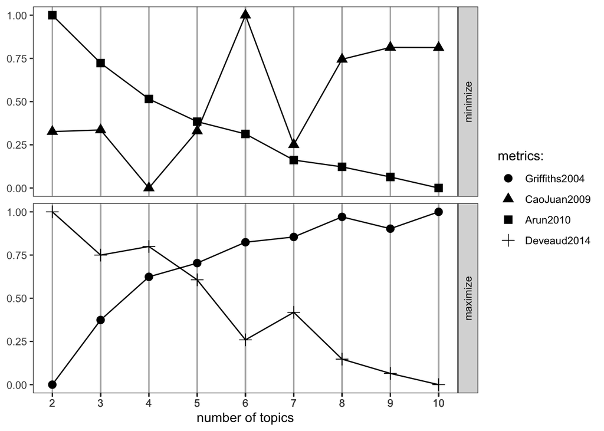

```r
FindTopicsNumber_plot(dtm_tune) #Early plotting of our LDA makes it seem likely that there are 4-5 distinct topics
```

```r
lda_results <- LDA(io_slim_dtm, 4)
lda_betas <- tidy(lda_results, matrix = "beta") %>%
  group_by(topic) %>%
  top_n(10, beta) %>%
  arrange(topic, -beta)

lda_gammas <- tidy(lda_results, matrix = "gamma")


lda_gammas <- lda_gammas %>%
  group_by(document) %>%
  top_n(1, gamma) %>%
  slice(1) %>%
  ungroup %>%
  mutate(document = as.numeric(document)) %>%
  arrange(document)
```

```r
tidy_og_corpus <- tidy(io_corpus_original) %>%
  select(id, text) %>%
  rename(document = id) %>%
  mutate(across(document, as.integer))

glimpse(tidy_og_corpus)
```

```
## Rows: 610
## Columns: 2
## $ document <int> 1, 2, 3, 4, 5, 6, 7, 8, 9, 10, 11, 12, 13, 14, 15, 16, 17, 18…
## $ text     <chr> "WOP-P", "Any recommendations for IO Psychology graduate prog…
```

```r
topics_tbl <- left_join(lda_gammas, tidy_og_corpus, by = "document") %>%
  rename(doc_id = document, original = text, probability = gamma)
```

When looking at the topics matched up with the original post titles I would definitely say it feels a bit muddier,but that makes a good deal of sense considering that the probability of each post being in assigned topic is about 25%. There seems to be a great deal of overlap between topics, especially with many relating to questions about grad school and work, but the general framing of the questions does appear to differ somewhat (in my totally unbiased opinion).

```r
io_tbl <- io_slim_dtm %>%
  as.matrix() %>%
  as.tibble()
```

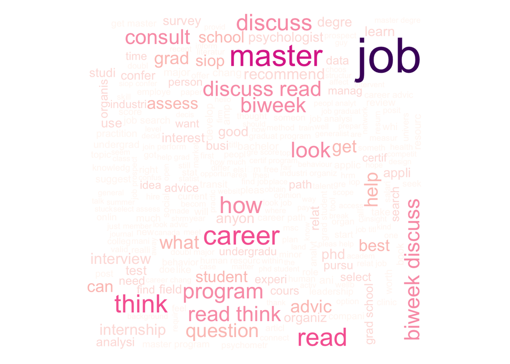

```r
wordcloud(
  words = names(io_tbl),
  freq = colSums(io_tbl),
  colors = brewer.pal(9,"RdPu")
)
```

I was a bit worried that the stemmed words would make the wordcloud look strange, but I think it actually turned out just fine

```r
tidy_og_corpus <- tidy(io_corpus_original) %>%
  select(id, text) %>%
  rename(document = id) %>%
  mutate(across(document, as.integer))

week12_tbl <- week12_tbl %>%
  rename(original = title)

final_tbl <- left_join(topics_tbl, week12_tbl, by = "original")
dummies <- dummy.code(final_tbl$topic)
dummies_tbl <- as.tibble(dummies)
names(dummies_tbl) <- c("topic1", "topic2", "topic3", "topic4")
final_tbl_dummied <- final_tbl %>%
  bind_cols(dummies_tbl)
```

```r
lm_1 <- lm (upvotes ~ topic1 + topic2 + topic3 + topic4, data = final_tbl_dummied)
summary(lm_1)
```

```
##
## Call:
## lm(formula = upvotes ~ topic1 + topic2 + topic3 + topic4, data = final_tbl_dummied)
##
## Residuals:
##    Min     1Q Median     3Q    Max
## -9.894 -2.602 -0.602  0.398 84.607
##
## Coefficients: (1 not defined because of singularities)
##             Estimate Std. Error t value Pr(>|t|)
## (Intercept)   8.6349     0.6339  13.621  < 2e-16 ***
## topic1       -3.0332     0.6826  -4.444 9.64e-06 ***
## topic2        0.7583     0.8285   0.915    0.360
## topic3        1.2590     0.8863   1.421    0.156
## topic4            NA         NA      NA       NA
## ---
## Signif. codes:  0 '***' 0.001 '**' 0.01 '*' 0.05 '.' 0.1 ' ' 1
##
## Residual standard error: 7.116 on 1223 degrees of freedom
## Multiple R-squared:  0.06069,    Adjusted R-squared:  0.05839
## F-statistic: 26.34 on 3 and 1223 DF,  p-value: < 2.2e-16
```

```r
set.seed(500)
holdout_indices <- createDataPartition(final_tbl_dummied$upvotes,
                                       p = .25,
                                       list = T)$Resample1

training_tbl <- final_tbl_dummied[holdout_indices,]
test_tbl <- final_tbl_dummied[-holdout_indices,]

training_folds <- createFolds(training_tbl$upvotes)

local_cluster <- makeCluster(7)
registerDoParallel(local_cluster)

xgb_upvotes <- train(
  upvotes ~ topic,
  training_tbl,
  method = "xgbLinear",
  na.action = na.pass,
  preProcess = c("center","scale", "nzv", "medianImpute"),
  trControl = trainControl(method = "cv",
                           number = 10,
                           verboseIter = TRUE,
                           indexOut = training_folds))
cv_xgb <- max(xgb_upvotes$results$Rsquared)
holdout_xgb <- cor(
  predict(xgb_upvotes, test_tbl, na.action = na.pass),
  test_tbl$upvotes
) ^ 2

cv_xgb
```

```
## [1] 0.1352035
```

```r
holdout_xgb
```

```
## [1] 0.03929452
```

```r
stopCluster(local_cluster)
registerDoSEQ()
```

When attempting to use xgboost to examine the relationship between topic and upvotes, our results suggest that we cannot predict upvotes based on topic. Our cv value is 0.1352035 and holdout prediction is 0.0392945.